# B402A Assignment 7

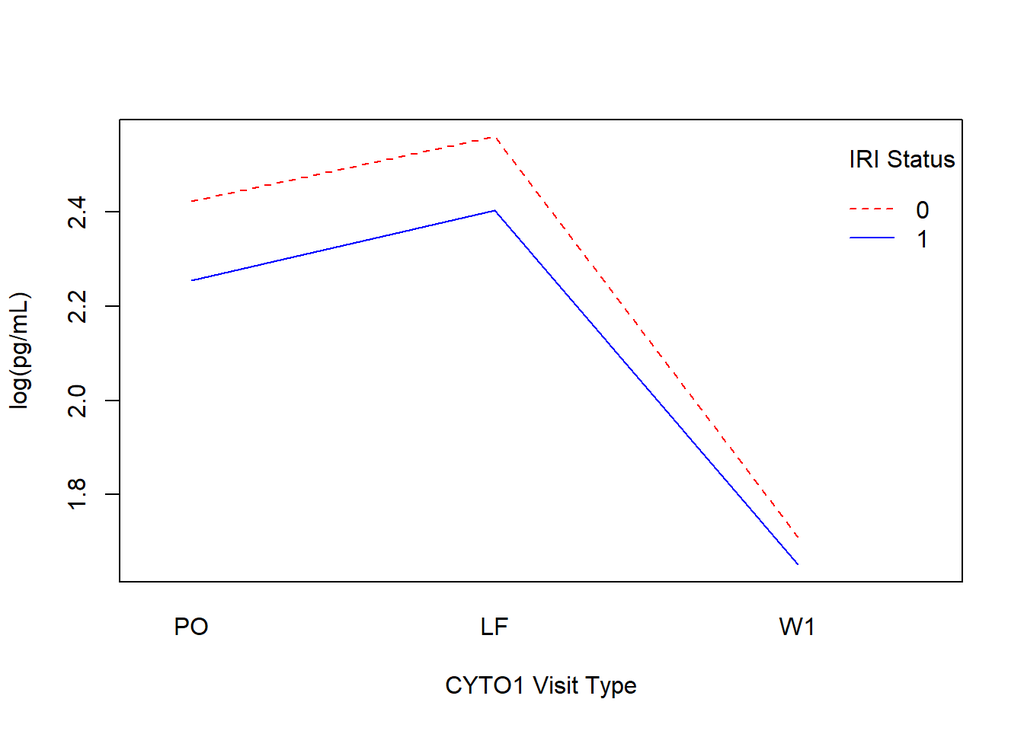

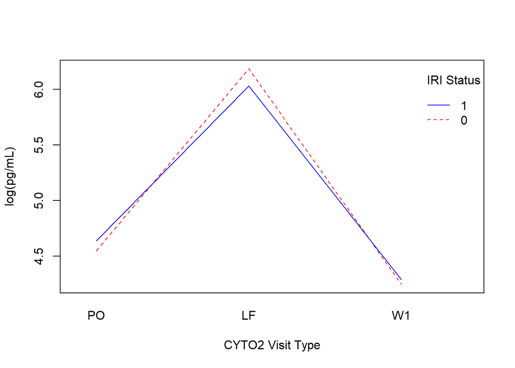

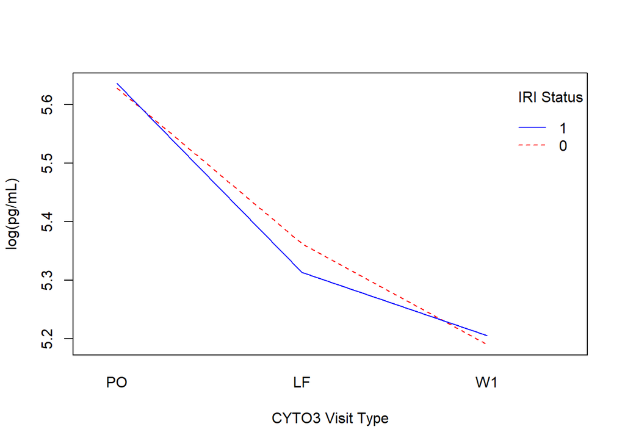

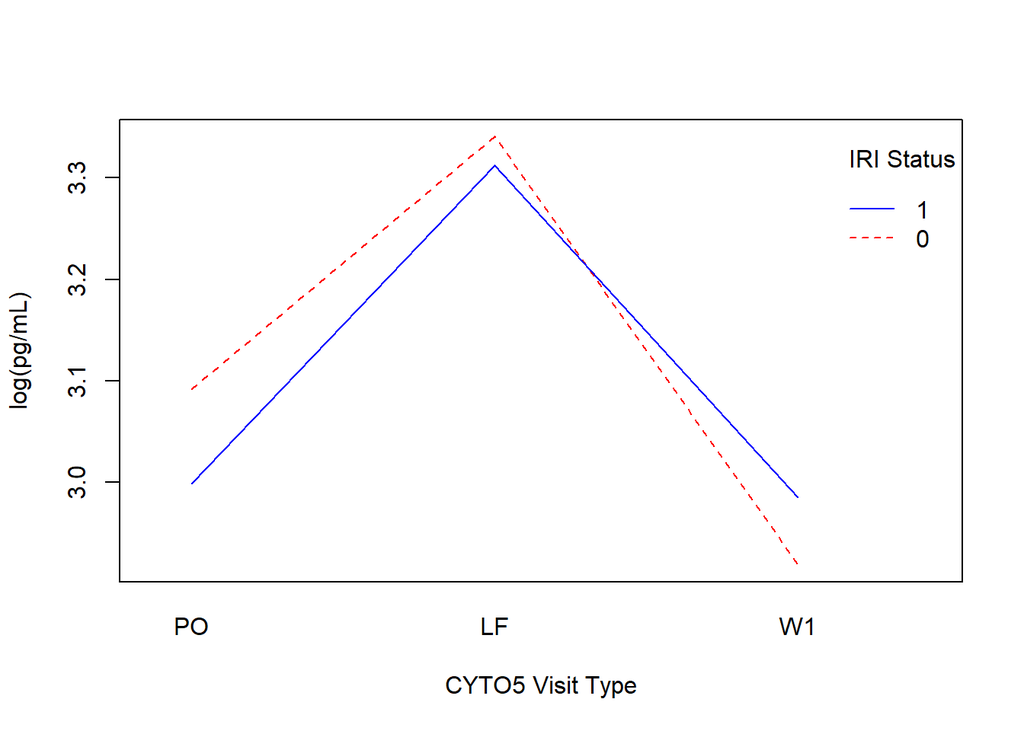

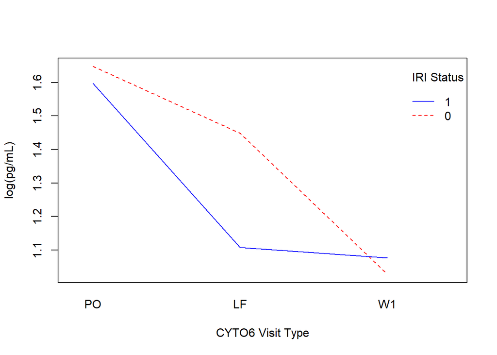

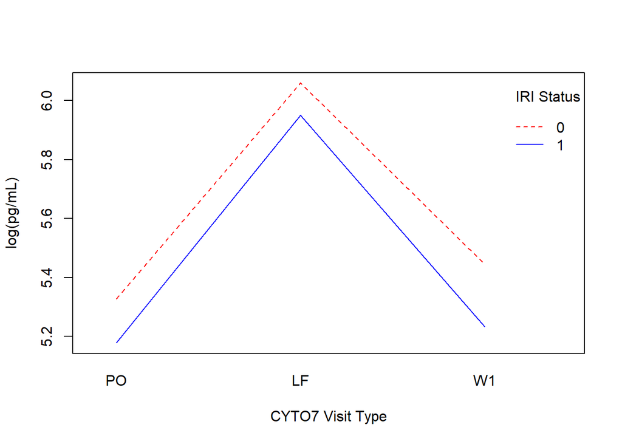

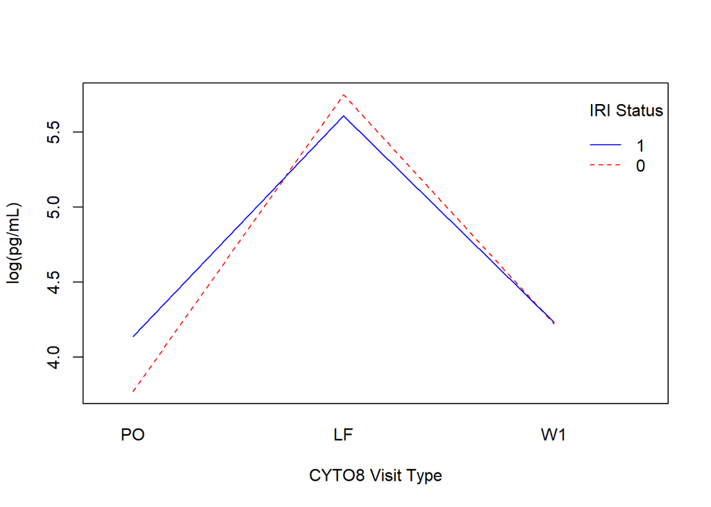

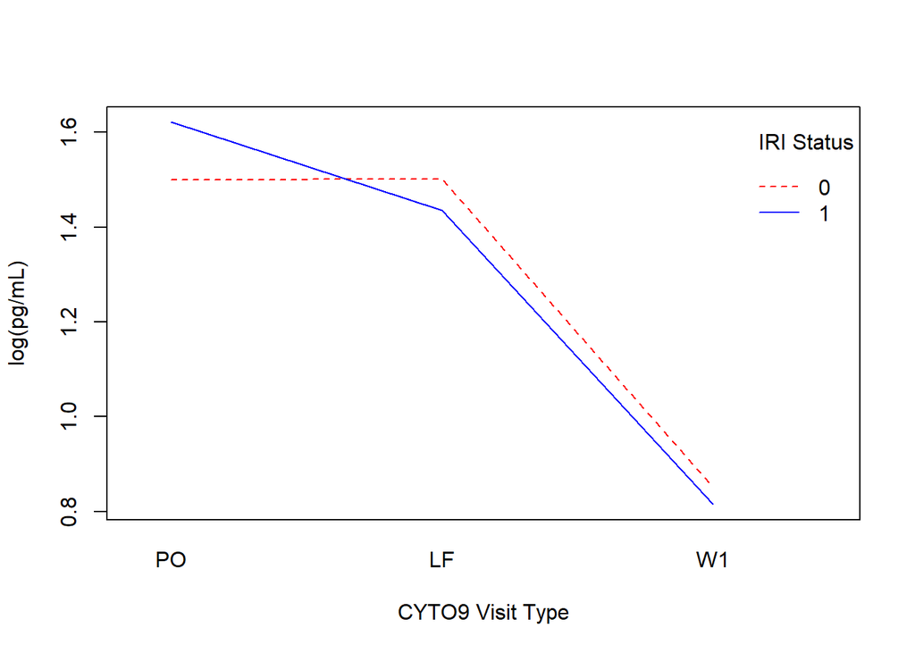

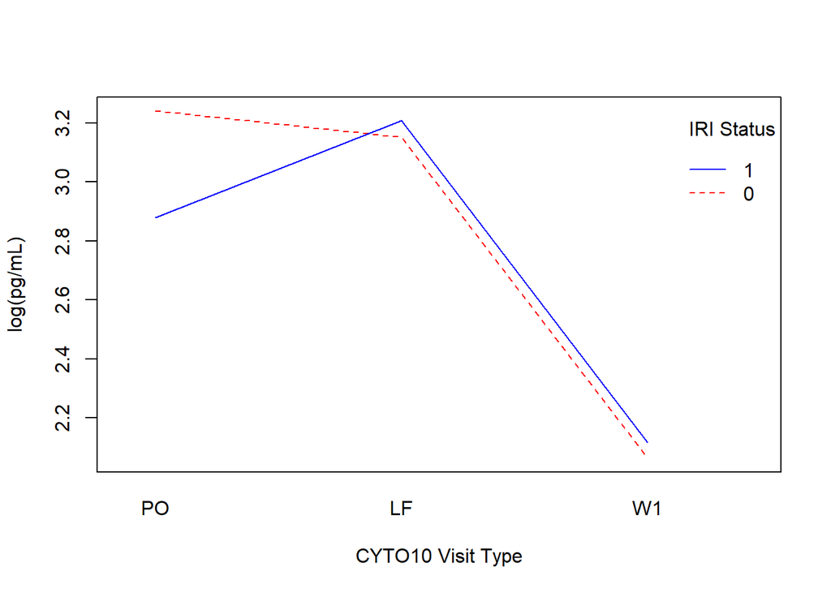

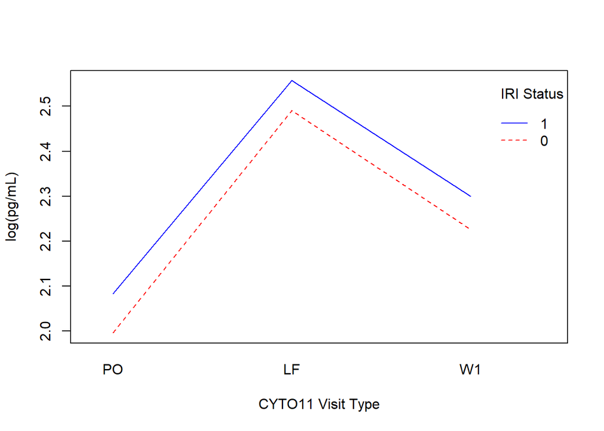

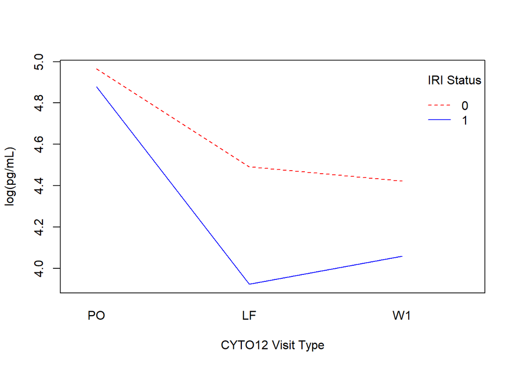

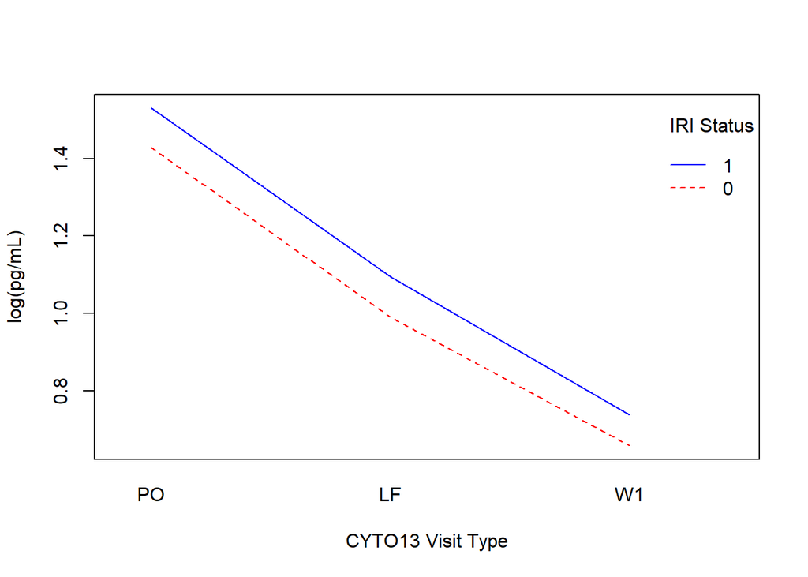

[8 more figures not shown]

```r
#need to add titles here
#I use median instead of mean due to outliers in data set
for(i in c(1:20)){
iri_tble2<- liri_tble %>% select(starts_with("CYTO"), -CYTO4, -CYTO16, -CYTO17)
    interaction.plot(x.factor = liri_tble$visittype,
                 response = liri_tble[[i]],
                 trace.factor = liri_tble$IRI,
                 fun = median,
                 ylab = "log(pg/mL)",
                 xlab = paste(names(iri_tble2)[i], "Visit Type"),
                 col = c("red", "blue"),
                 trace.label = "IRI Status")
}
```

To explore whether IRI status explains variation in cytokine concentrations, two-way anovas will be conducted with IRI status and visit type as factor levels. A separate anova for each cytokine concentration will be conducted.

Running 2-Way ANOVA

```r
twoway_modelList    <- lapply(responseList, function(resp) {
                           mF <- formula(paste(resp, " ~ visittype*IRI"))
                           anova(lm(mF, data = isi_tble))
                })
twoway_modelList
```

```
## [[1]]
## Analysis of Variance Table
##
## Response: CYTO1
##                Df     Sum Sq Mean Sq F value Pr(>F)
## visittype       2   10755178 5377589  0.9785 0.3771
## IRI             1    7664312 7664312  1.3946 0.2386
## visittype:IRI   2   15242052 7621026  1.3867 0.2515
## Residuals     294 1615708005 5495605
##
## [[2]]
## Analysis of Variance Table
##
## Response: CYTO2
##                Df   Sum Sq Mean Sq F value Pr(>F)
## visittype       2 15252800 7626400 51.8650 <2e-16 ***
## IRI             1   126116  126116  0.8577 0.3551
## visittype:IRI   2   149221   74611  0.5074 0.6026
## Residuals     294 43230701  147043
## ---
## Signif. codes:  0 '***' 0.001 '**' 0.01 '*' 0.05 '.' 0.1 ' ' 1
##
## [[3]]
## Analysis of Variance Table
##
## Response: CYTO3
##                Df  Sum Sq Mean Sq F value    Pr(>F)
## visittype       2  855087  427543 13.7892 1.888e-06 ***
## IRI             1       1       1  0.0000    0.9946
## visittype:IRI   2    1846     923  0.0298    0.9707
## Residuals     294 9115680   31006
## ---
## Signif. codes:  0 '***' 0.001 '**' 0.01 '*' 0.05 '.' 0.1 ' ' 1
##
## [[4]]
## Analysis of Variance Table
##
## Response: CYTO4
##                Df Sum Sq Mean Sq F value Pr(>F)
## visittype       2   1603  801.51  0.3167 0.7288
```

[output cut: 210 more lines]

```
## Residuals     294 2463786    8380
## ---
## Signif. codes:  0 '***' 0.001 '**' 0.01 '*' 0.05 '.' 0.1 ' ' 1
##
## [[23]]
## Analysis of Variance Table
##
## Response: CYTO23
##                Df Sum Sq Mean Sq F value  Pr(>F)
## visittype       2  13467  6733.6 45.7942 < 2e-16 ***
## IRI             1    584   583.6  3.9687 0.04728 *
## visittype:IRI   2    263   131.7  0.8954 0.40955
## Residuals     294  43230   147.0
## ---
## Signif. codes:  0 '***' 0.001 '**' 0.01 '*' 0.05 '.' 0.1 ' ' 1
```

A significant interaction is not observed in any of the models between IRI and visittype. IRI effect is significant explaining the variation in CYTO23 and CYTO22, which indicates IRI status is associated with CYTO23 and CYTO22 given visit type.

Running Logistic Regression Models - Main Effects and Select Interactions

Correlation Plots

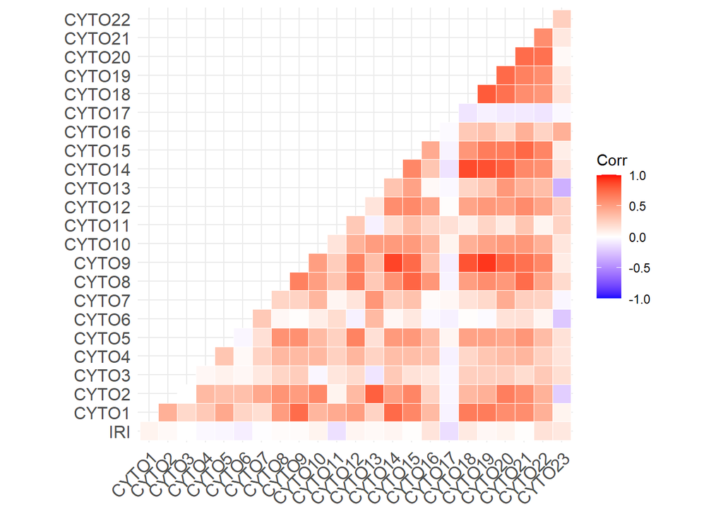

```r
library(ggcorrplot)
corr.main <- round(cor(logdataclean[,c(3, 7:29)]), 3)
corr.change <- round(cor(changesubset[,3:26]), 3)
pcorr.change <- round(cor_pmat(changesubset[,3:26]), 3)

corr.diff1 <- round(cor(diff1subset[,3:26]), 3)
pcorr.diff1 <- round(cor_pmat(diff1subset[,3:26]), 3)

corr.diff2 <- round(cor(diff2subset[,3:26]), 3)
pcorr.diff2 <- round(cor_pmat(diff2subset[,3:26]), 3)

ggcorrplot(corr.main, outline.col = "white", type = "lower")
```

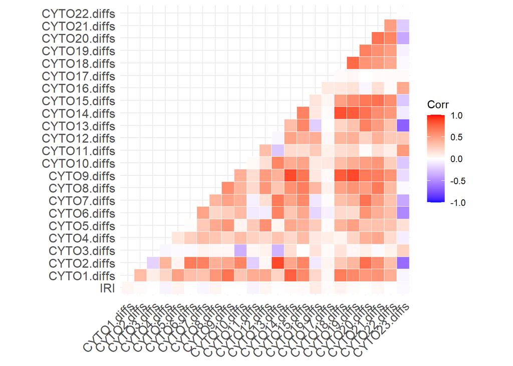

```r
ggcorrplot(corr.change, outline.col = "white", type = "lower")
```

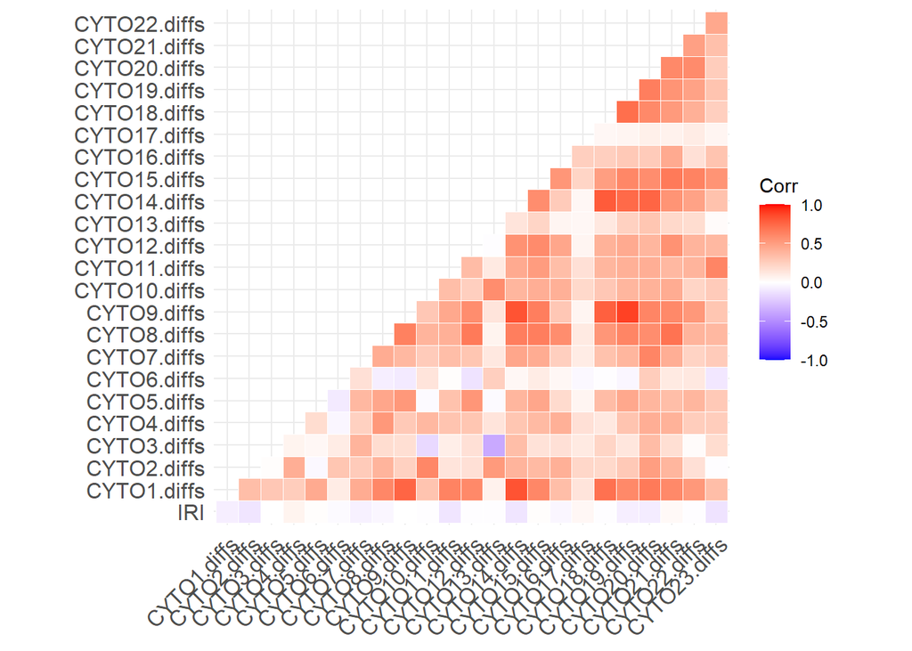

```r
ggcorrplot(corr.diff1, outline.col = "white", type = "lower")
```

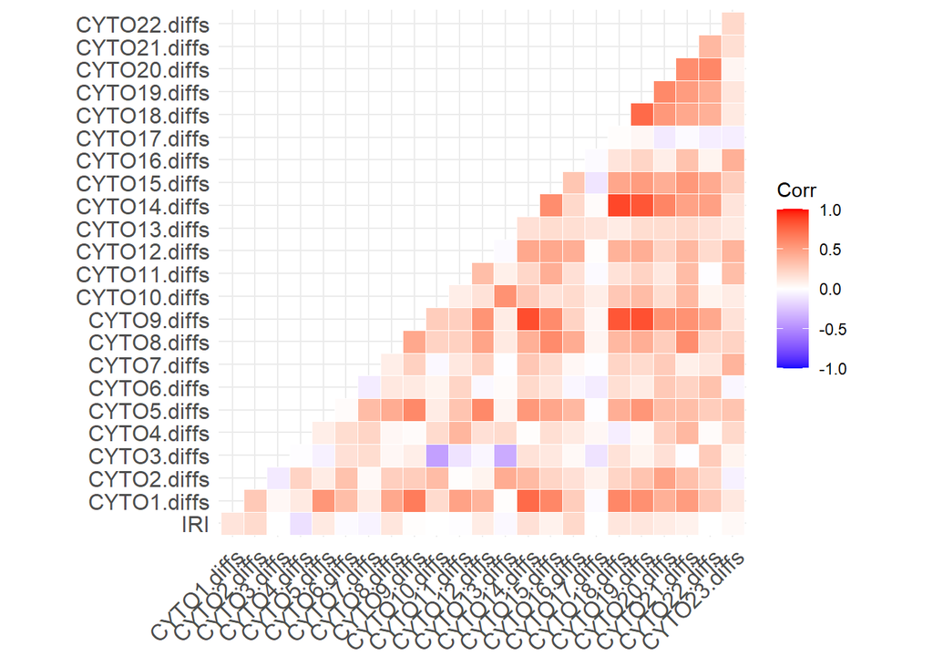

```r
ggcorrplot(corr.diff2, outline.col = "white", type = "lower")
```

#### Main Effects Logistic Regression Models

For the logistic regression model containing main effects for all log-transformed cytokines (except CYTO17), we see significant coefficients for CYTO1, CYTO16, CYTO18, and CYTO22 at the $\alpha = 0.1$ level. We can interpret the coefficients as follows (using CYTO22 as example): for every 1 unit increase in CYTO22, the odds of being IRI+ increase by 1.51 times.

Logistic regression models for main effects were also stratified by visit type (PO, LF, and W1). For the logistic regression model containing main effects for all log-transformed cytokines (except CYTO17) for only PO visits, we see significant coefficients for CYTO3, CYTO15, CYTO16, and CYTO23 at the $\alpha = 0.1$ level. We can interpret the coefficients as follows (using CYTO23 as example): for every 1 unit increase in CYTO23, the odds of being IRI+ increase by 2.15 times.

For the logistic regression model containing main effects for all log-transformed cytokines (except CYTO17) for only LF visits, we see significant coefficients for CYTO1, CYTO2, CYTO11, CYTO13, and CYTO14 at the $\alpha = 0.1$ level. We can interpret the coefficients as follows (using CYTO14 as example): for every 1 unit increase in CYTO14, the odds of being IRI+ increase by 0.29 times (decrease by 71%).

For the logistic regression model containing main effects for all log-transformed cytokines (except CYTO17) for only W1 visits, we see significant coefficients for CYTO9, CYTO13, CYTO18, and CYTO22 at the $\alpha = 0.1$ level. We can interpret the coefficients as follows (using CYTO22 as example): for every 1 unit increase in CYTO22, the odds of being IRI+ increase by 4.73 times.

#### Stepwise Main Effects + Interactions Logistic Regression Models

The significant predictors from the main effects model were then utilized to fit a logistic regression model including 2-way interactions for those predictors. Then, stepwise selection was conducted to find the logistic regression model with the lowest AIC while retaining meaningful predictors. For the stepwise selection of the logistic regression model containing main + interaction effects for all log-transformed cytokines (except CYTO17), we see significant coefficients for the intercept, CYTO16 and CYTO22 at the $\alpha = 0.1$ level (no significant interactions). We can interpret the coefficients as follows (using CYTO22 as example): for every 1 unit increase in CYTO22, the odds of being IRI+ increase by 1.24 times.

For the stepwise selection of the logistic regression model containing main + interaction effects for all log-transformed cytokines (except CYTO17) for only PO visits, we see significant coefficients for the intercept and the interaction CYTO3:CYTO15 at the $\alpha = 0.1$ level. Because there is a significant interaction, it may be possible that CYTO3 and CYTO15 vary together, although neither CYTO3 or CYTO15 are significant at the $\alpha = 0.1$ level.

For the stepwise selection of the logistic regression model containing main + interaction effects for all log-transformed cytokines (except CYTO17) for only LF visits, we see significant coefficients for the intercept, CYTO2 and CYTO11 at the $\alpha = 0.1$ level (no significant interactions).

For the stepwise selection of the logistic regression model containing main + interaction effects for all log-transformed cytokines (except CYTO17) for only W1 visits, we see significant coefficients for the intercept, CYTO9, CYTO18, CYTO22, the interaction CYTO13:CYTO18, and the interaction CYTO13:CYTO22 at the $\alpha = 0.1$ level. Because there are significant interactions, it is possible that CYTO13, CYTO18, CYTO22 vary together at this time point.

#### Logistic Regression Using Log Differences in Consecutive Visits

For the logistic regression model containing main effects for change in log-transformed cytokines (except CYTO17) for PO to LF and LF to W1, we see significant coefficients for CYTO9 at the $\alpha = 0.1$ level. We can interpret the coefficients as follows: for every 1 unit increase in the change of CYTO9, the odds of being IRI+ increase by 0.65 times (decrease by 35%).

For the logistic regression model containing main effects for change in log-transformed cytokines (except CYTO17) from PO to LF, we see significant coefficients for the intercept, CYTO2, CYTO3, CYTO4, CYTO9, CYTO10, CYTO14, and CYTO19 at the $\alpha = 0.1$ level. We can interpret the coefficients as follows (using CYTO19 as example): for every 1 unit increase in the change of CYTO19, the odds of being IRI+ increase by 0.30 times (decrease by 70%).

For the logistic regression model containing main effects for change in log-transformed cytokines (except CYTO17) from LF to W1, we see significant coefficients for CYTO2 and CYTO9 at the $\alpha = 0.1$ level. We can interpret the coefficients as follows (using CYTO9 as example): for every 1 unit increase in the change of CYTO9, the odds of being IRI+ increase by 0.25 times (decrease by 75%).

```r
# did not include interaction model for change models due to not all models converging

main.table
```

| **Characteristic** | **OR**<sup>1</sup> | **95% CI**<sup>1</sup> | **p-value** |
| --- | --- | --- | --- |
| (Intercept) | 0.22 | 0.01, 7.96 | 0.4 |
| CYTO1 | 1.50 | 1.04, 2.35 | 0.054 |
| CYTO16 | 1.36 | 0.97, 1.92 | 0.081 |
| CYTO18 | 1.26 | 1.03, 1.65 | 0.046 |
| CYTO22 | 1.51 | 1.07, 2.15 | 0.020 |

<sup>*1*</sup> OR = Odds Ratio, CI = Confidence Interval

```r
po.table
```

| **Characteristic** | **OR**<sup>1</sup> | **95% CI**<sup>1</sup> | **p-value** |
| --- | --- | --- | --- |
| (Intercept) | 0.25 | 0.00, 267 | 0.7 |
| CYTO3 | 0.59 | 0.31, 1.07 | 0.091 |
| CYTO15 | 0.40 | 0.14, 1.03 | 0.070 |
| CYTO16 | 1.95 | 0.92, 4.46 | 0.094 |
| CYTO23 | 2.15 | 0.95, 5.23 | 0.077 |

<sup>*1*</sup> OR = Odds Ratio, CI = Confidence Interval

```r
lf.table
```

| **Characteristic** | **OR**<sup>1</sup> | **95% CI**<sup>1</sup> | **p-value** |
| --- | --- | --- | --- |
| (Intercept) | 0.14 | 0.00, 42,622 | 0.8 |
| CYTO1 | 3.32 | 1.08, 11.6 | 0.044 |
| CYTO2 | 0.31 | 0.11, 0.75 | 0.017 |
| CYTO11 | 0.58 | 0.32, 0.98 | 0.049 |
| CYTO13 | 1.57 | 0.98, 2.68 | 0.075 |
| CYTO14 | 0.29 | 0.06, 0.84 | 0.054 |

<sup>*1*</sup> OR = Odds Ratio, CI = Confidence Interval

```r
w1.table
```

| **Characteristic** | **OR**<sup>1</sup> | **95% CI**<sup>1</sup> | **p-value** |
| --- | --- | --- | --- |
| (Intercept) | 0.83 | 0.00, 24,579 | >0.9 |
| CYTO9 | 0.35 | 0.11, 0.94 | 0.048 |
| CYTO13 | 0.56 | 0.27, 1.06 | 0.088 |
| CYTO18 | 2.07 | 1.03, 5.00 | 0.070 |
| CYTO22 | 4.73 | 1.42, 18.8 | 0.016 |

<sup>*1*</sup> OR = Odds Ratio, CI = Confidence Interval

```r
stepint.table
```

| **Characteristic** | **OR**<sup>1</sup> | **95% CI**<sup>1</sup> | **p-value** |
| --- | --- | --- | --- |
| (Intercept) | 0.18 | 0.05, 0.58 | 0.004 |
| CYTO16 | 1.24 | 0.99, 1.58 | 0.063 |
| CYTO22 | 1.24 | 1.02, 1.52 | 0.031 |

<sup>*1*</sup> OR = Odds Ratio, CI = Confidence Interval

```r
steppoint.table
```

| **Characteristic** | **OR**<sup>1</sup> | **95% CI**<sup>1</sup> | **p-value** |
| --- | --- | --- | --- |
| (Intercept) | 0.00 | 0.00, 0.54 | 0.045 |
| CYTO3 | 2.22 | 0.86, 6.38 | 0.11 |
| CYTO15 | 6.68 | 0.52, 142 | 0.2 |
| CYTO23 | 1.26 | 0.50, 3.35 | 0.6 |
| CYTO3 * CYTO15 | 0.64 | 0.41, 0.95 | 0.036 |
| CYTO15 * CYTO23 | 1.42 | 0.92, 2.27 | 0.13 |

<sup>*1*</sup> OR = Odds Ratio, CI = Confidence Interval

```r
steplfint.table
```

| **Characteristic** | **OR**<sup>1</sup> | **95% CI**<sup>1</sup> | **p-value** |
| --- | --- | --- | --- |
| (Intercept) | 34,504 | 1.64, 3,098,358,817 | 0.051 |
| CYTO1 | 1.80 | 0.87, 3.86 | 0.12 |
| CYTO2 | 0.43 | 0.23, 0.76 | 0.006 |
| CYTO11 | 0.22 | 0.04, 0.92 | 0.050 |
| CYTO13 | 0.88 | 0.38, 1.88 | 0.8 |
| CYTO14 | 0.77 | 0.54, 1.07 | 0.12 |
| CYTO11 * CYTO13 | 1.10 | 0.98, 1.26 | 0.13 |

<sup>*1*</sup> OR = Odds Ratio, CI = Confidence Interval

```r
stepw1int.table
```

| **Characteristic** | **OR**<sup>1</sup> | **95% CI**<sup>1</sup> | **p-value** |
| --- | --- | --- | --- |
| (Intercept) | 0.00 | 0.00, 0.13 | 0.045 |
| CYTO9 | 0.27 | 0.11, 0.57 | 0.001 |
| CYTO13 | 4.04 | 0.30, 81.7 | 0.3 |
| CYTO18 | 0.21 | 0.03, 1.06 | 0.066 |
| CYTO22 | 614 | 8.84, 143,726 | 0.008 |
| CYTO13 * CYTO18 | 1.43 | 1.11, 1.94 | 0.011 |
| CYTO13 * CYTO22 | 0.45 | 0.19, 0.86 | 0.030 |

<sup>*1*</sup> OR = Odds Ratio, CI = Confidence Interval

```r
changemain.table
```

| **Characteristic** | **OR**<sup>1</sup> | **95% CI**<sup>1</sup> | **p-value** |
| --- | --- | --- | --- |
| (Intercept) | 0.78 | 0.51, 1.18 | 0.2 |
| CYTO9.diffs | 0.65 | 0.38, 1.04 | 0.084 |

<sup>*1*</sup> OR = Odds Ratio, CI = Confidence Interval

```r
changemainbase.table
```

| **Characteristic** | **OR**<sup>1</sup> | **95% CI**<sup>1</sup> | **p-value** |
| --- | --- | --- | --- |
| (Intercept) | 0.23 | 0.00, 74.3 | 0.6 |
| CYTO9.diffs | 0.58 | 0.29, 1.08 | 0.10 |
| CYTO1 | 2.25 | 0.99, 5.27 | 0.056 |
| CYTO3 | 0.58 | 0.34, 0.95 | 0.035 |
| CYTO15 | 0.44 | 0.20, 0.94 | 0.039 |
| CYTO16 | 2.04 | 1.09, 4.03 | 0.031 |
| CYTO23 | 2.19 | 1.15, 4.35 | 0.020 |

<sup>*1*</sup> OR = Odds Ratio, CI = Confidence Interval

```r
changemain1.table
```

| **Characteristic** | **OR**<sup>1</sup> | **95% CI**<sup>1</sup> | **p-value** |
| --- | --- | --- | --- |
| (Intercept) | 0.17 | 0.03, 0.91 | 0.045 |
| CYTO2.diffs | 0.56 | 0.30, 0.97 | 0.051 |
| CYTO3.diffs | 1.89 | 0.96, 3.99 | 0.076 |
| CYTO4.diffs | 1.66 | 1.07, 2.77 | 0.035 |
| CYTO9.diffs | 4.21 | 1.33, 16.5 | 0.024 |
| CYTO10.diffs | 1.87 | 1.00, 3.89 | 0.068 |
| CYTO14.diffs | 0.42 | 0.19, 0.84 | 0.022 |
| CYTO19.diffs | 0.30 | 0.08, 0.89 | 0.060 |

<sup>*1*</sup> OR = Odds Ratio, CI = Confidence Interval

```r
changemain2.table
```

| **Characteristic** | **OR**<sup>1</sup> | **95% CI**<sup>1</sup> | **p-value** |
| --- | --- | --- | --- |
| (Intercept) | 0.23 | 0.02, 2.09 | 0.2 |
| CYTO2.diffs | 1.55 | 1.01, 2.52 | 0.058 |
| CYTO9.diffs | 0.25 | 0.10, 0.55 | 0.001 |

<sup>*1*</sup> OR = Odds Ratio, CI = Confidence Interval

A logistic model with random intercept per patient was also ran. This model aims to capture variation within each subject for each timepoint. We see that none of the predictors are significant. It is important to note that the method used to run this model may be biased, and the results should be taken with some skepticism.

```r
library(lme4)
library(MASS)


#liri_tble[ ,c(1:23)] <- scale(liri_tble[ ,c(1:23)])

CYTO <- names(liri_tble[1:23])
eqn <- as.formula(paste("IRI ~ (1 | ID)", paste(CYTO, collapse = " + "), sep = "+"))

liri_tble$visittype <- as.numeric(liri_tble$visittype)
#logistic mixed model using time and intercept as a mrandom effect for each patient ID
random <- glmer(eqn, data = liri_tble, family = binomial, nAGQ = 0, control=glmerControl(optimizer="bobyqa"))
summary(random)
```

```
## Generalized linear mixed model fit by maximum likelihood (Adaptive
##   Gauss-Hermite Quadrature, nAGQ = 0) [glmerMod]
##  Family: binomial  ( logit )
## Formula: IRI ~ (1 | ID) + CYTO1 + CYTO2 + CYTO3 + CYTO4 + CYTO5 + CYTO6 +
##     CYTO7 + CYTO8 + CYTO9 + CYTO10 + CYTO11 + CYTO12 + CYTO13 +
##     CYTO14 + CYTO15 + CYTO16 + CYTO17 + CYTO18 + CYTO19 + CYTO20 +
##     CYTO21 + CYTO22 + CYTO23
##    Data: liri_tble
## Control: glmerControl(optimizer = "bobyqa")
##
##      AIC      BIC   logLik deviance df.resid
##    230.1    322.7    -90.1    180.1      275
##
## Scaled residuals:
##      Min       1Q   Median       3Q      Max
## -0.20474 -0.11081 -0.07526  0.11669  0.21861
##
## Random effects:
##  Groups Name        Variance Std.Dev.
##  ID     (Intercept) 95.95    9.795
## Number of obs: 300, groups:  ID, 100
##
## Fixed effects:
##             Estimate Std. Error z value Pr(>|z|)
## (Intercept) -1.32589   10.40342  -0.127    0.899
## CYTO1        0.75603    1.81737   0.416    0.677
## CYTO2        0.22492    1.21913   0.184    0.854
## CYTO3       -0.16697    1.34745  -0.124    0.901
## CYTO4       -0.09345    0.72447  -0.129    0.897
## CYTO5       -0.19017    0.55815  -0.341    0.733
## CYTO6       -0.35968    1.01224  -0.355    0.722
## CYTO7        0.06613    0.66253   0.100    0.920
## CYTO8       -0.01857    0.99660  -0.019    0.985
## CYTO9       -0.36080    1.85374  -0.195    0.846
## CYTO10      -0.02828    1.34454  -0.021    0.983
## CYTO11      -0.30705    0.92635  -0.331    0.740
## CYTO12       0.24520    0.84513   0.290    0.772
## CYTO13       0.08171    0.62510   0.131    0.896
## CYTO14      -0.41407    1.14959  -0.360    0.719
## CYTO15      -0.44441    1.62660  -0.273    0.785
## CYTO16       0.46918    1.39166   0.337    0.736
## CYTO17      -2.20861    3.94256  -0.560    0.575
## CYTO18       0.29932    0.73467   0.407    0.684
## CYTO19       0.09505    1.50139   0.063    0.950
## CYTO20       0.03489    1.19422   0.029    0.977
## CYTO21      -0.28314    1.51606  -0.187    0.852
## CYTO22       0.64339    1.31607   0.489    0.625
## CYTO23       0.34889    1.68086   0.208    0.836
```

## Analysis of data set:

Question 2: What cytokines in the pre-transplant blood sample specifically correlate with:

1. Immune cell infiltration after transplant? (Inflammation score)

Since we are looking at cytokines in pre-transplant blood samples, we first filter for pre-operation data.

```r
# filter for preoperation data
dataPO <- dataclean %>%
  filter(visittype == "PO")

# crosstabs on preoperation data
xtabs(~ Inflammation, data = dataPO)
```

```
## Inflammation
##  0  1  2  3
##  9 59 26  6
```

```r
xtabs(~ Necrosis, data = dataPO)
```

```
## Necrosis
##  0  1  2  3  4
## 25 37 24 12  2
```

We reassign the numerical inflammation scores to reflect negative and positive scores.

```r
dataPO1 <- dataPO

# reassigning inflammation scores 0=negative and 2=positive
dataPO1$Inflammation[dataPO$Inflammation == 0] <- 0
dataPO1$Inflammation[dataPO$Inflammation == 1] <- 0

dataPO1$Inflammation[dataPO$Inflammation == 2] <- 2
dataPO1$Inflammation[dataPO$Inflammation == 3] <- 2
dataPO1$Inflammation[dataPO$Inflammation == 4] <- 2


# reassigning necrosis scores 0=negative and 2=positive
dataPO1$Necrosis[dataPO$Necrosis == 0] <- 0
dataPO1$Necrosis[dataPO$Necrosis == 1] <- 0

dataPO1$Necrosis[dataPO$Necrosis == 2] <- 2
dataPO1$Necrosis[dataPO$Necrosis == 3] <- 2
dataPO1$Necrosis[dataPO$Necrosis == 4] <- 2

# crosstabs to check that reassigned values match original data
xtabs(~ Inflammation, data = dataPO1)
```

```
## Inflammation
##  0  2
## 68 32
```

```r
xtabs(~ Necrosis, data = dataPO1)
```

```
## Necrosis
##  0  2
## 62 38
```

We attempt an ordinal logistic regression model with the numeric inflammation scores. The confidence interval for cytokine 23 does not include 0, which suggests that it may be statistically significant.

```r
library(MASS)
# releveled inflammation as factor
dataPO$Inflammation <- factor(dataPO$Inflammation, levels = c("0", "1", "2", "3", "4"))
dataPO$Inflammation
```

```
##   [1] 1 1 1 1 2 2 2 1 3 1 1 1 3 0 2 3 2 2 1 1 2 1 2 1 2 1 1 1 2 1 2 2 1 1 1 1 1
##  [38] 1 1 1 3 1 2 1 1 1 2 1 3 1 1 2 2 1 1 1 3 1 1 1 2 1 2 1 2 2 1 2 1 1 0 1 1 1
##  [75] 1 1 1 2 1 1 0 1 2 1 1 1 0 2 1 2 1 1 0 2 0 0 0 1 0 1
## Levels: 0 1 2 3 4
```

```r
# ordinal logistic regression model
m1 <- polr(Inflammation ~ CYTO1 + CYTO2 + CYTO3 + CYTO4 + CYTO5 + CYTO6 + CYTO7
           + CYTO8 + CYTO9 + CYTO10 + CYTO11 + CYTO12 + CYTO13 + CYTO14 + CYTO15
           + CYTO16 + CYTO18 + CYTO19 + CYTO20 + CYTO21 + CYTO22 + CYTO23,
           data = dataPO, Hess=TRUE)
summary(m1)
```

```
## Call:
## polr(formula = Inflammation ~ CYTO1 + CYTO2 + CYTO3 + CYTO4 +
##     CYTO5 + CYTO6 + CYTO7 + CYTO8 + CYTO9 + CYTO10 + CYTO11 +
##     CYTO12 + CYTO13 + CYTO14 + CYTO15 + CYTO16 + CYTO18 + CYTO19 +
##     CYTO20 + CYTO21 + CYTO22 + CYTO23, data = dataPO, Hess = TRUE)
##
## Coefficients:
##             Value Std. Error  t value
## CYTO1   0.0990972  0.0607496  1.63124
## CYTO2  -0.0041909  0.0037136 -1.12854
## CYTO3  -0.0015958  0.0012598 -1.26675
## CYTO4  -0.0185309  0.0103424 -1.79174
## CYTO5   0.0010193  0.0018938  0.53824
## CYTO6   0.0011034  0.0011182  0.98678
## CYTO7   0.0012252  0.0012310  0.99532
## CYTO8   0.0007049  0.0140244  0.05026
## CYTO9   0.0081579  0.0136709  0.59674
## CYTO10 -0.0244423  0.0350566 -0.69722
## CYTO11 -0.0026796  0.0015254 -1.75668
## CYTO12 -0.0264420  0.0223970 -1.18060
## CYTO13 -0.0005690  0.0007607 -0.74808
## CYTO14 -0.0046667  0.0035552 -1.31264
## CYTO15  0.0227108  0.0506707  0.44820
## CYTO16  0.2700851  0.1510910  1.78757
## CYTO18 -0.0003892  0.0002172 -1.79196
## CYTO19  0.0405524  0.0356837  1.13644
## CYTO20 -0.0008111  0.0007264 -1.11657
## CYTO21  0.0233837  0.0277171  0.84366
## CYTO22 -0.0004304  0.0024876 -0.17303
## CYTO23  0.0578270  0.0223748  2.58447
##
## Intercepts:
##     Value   Std. Error t value
## 0|1 -2.0028  0.6858    -2.9204
## 1|2  1.8115  0.6294     2.8781
## 2|3  4.4719  0.8403     5.3217
## 3|4 23.4397  0.8402    27.8988
##
## Residual Deviance: 170.8675
## AIC: 222.8675
```

```r
## store table
(ctable1 <- coef(summary(m1)))
```

```
##                Value   Std. Error     t value
## CYTO1   0.0990972489 0.0607495853  1.63124157
## CYTO2  -0.0041909214 0.0037135846 -1.12853801
## CYTO3  -0.0015957931 0.0012597556 -1.26674817
## CYTO4  -0.0185309221 0.0103423908 -1.79174453
## CYTO5   0.0010193281 0.0018938064  0.53824307
## CYTO6   0.0011033743 0.0011181528  0.98678309
## CYTO7   0.0012252488 0.0012310094  0.99532041
## CYTO8   0.0007049127 0.0140243958  0.05026332
## CYTO9   0.0081579103 0.0136709009  0.59673538
## CYTO10 -0.0244423105 0.0350565760 -0.69722469
## CYTO11 -0.0026795576 0.0015253564 -1.75667638
## CYTO12 -0.0264420415 0.0223970444 -1.18060406
## CYTO13 -0.0005690480 0.0007606737 -0.74808429
## CYTO14 -0.0046667285 0.0035552334 -1.31263633
## CYTO15  0.0227107980 0.0506706904  0.44820384
## CYTO16  0.2700850984 0.1510910309  1.78756540
## CYTO18 -0.0003892376 0.0002172136 -1.79195821
## CYTO19  0.0405524257 0.0356837272  1.13644030
## CYTO20 -0.0008110602 0.0007263833 -1.11657342
## CYTO21  0.0233837014 0.0277170687  0.84365709
## CYTO22 -0.0004304278 0.0024876217 -0.17302785
## CYTO23  0.0578269674 0.0223747943  2.58446923
## 0|1    -2.0028022044 0.6857895393 -2.92043271
## 1|2     1.8114728183 0.6293997691  2.87809578
## 2|3     4.4719234340 0.8403158047  5.32171763
## 3|4    23.4396652631 0.8401688914 27.89875405
```

```r
## calculate and store p values
p1 <- pnorm(abs(ctable1[, "t value"]), lower.tail = FALSE) * 2

## combined table
(ctable1 <- cbind(ctable1, "p value" = p1))
```

```
##                Value   Std. Error     t value       p value
## CYTO1   0.0990972489 0.0607495853  1.63124157  1.028394e-01
## CYTO2  -0.0041909214 0.0037135846 -1.12853801  2.590928e-01
## CYTO3  -0.0015957931 0.0012597556 -1.26674817  2.052453e-01
## CYTO4  -0.0185309221 0.0103423908 -1.79174453  7.317390e-02
## CYTO5   0.0010193281 0.0018938064  0.53824307  5.904093e-01
## CYTO6   0.0011033743 0.0011181528  0.98678309  3.237490e-01
## CYTO7   0.0012252488 0.0012310094  0.99532041  3.195805e-01
## CYTO8   0.0007049127 0.0140243958  0.05026332  9.599126e-01
## CYTO9   0.0081579103 0.0136709009  0.59673538  5.506841e-01
## CYTO10 -0.0244423105 0.0350565760 -0.69722469  4.856622e-01
## CYTO11 -0.0026795576 0.0015253564 -1.75667638  7.897299e-02
## CYTO12 -0.0264420415 0.0223970444 -1.18060406  2.377601e-01
## CYTO13 -0.0005690480 0.0007606737 -0.74808429  4.544093e-01
## CYTO14 -0.0046667285 0.0035552334 -1.31263633  1.893055e-01
## CYTO15  0.0227107980 0.0506706904  0.44820384  6.540061e-01
## CYTO16  0.2700850984 0.1510910309  1.78756540  7.384615e-02
## CYTO18 -0.0003892376 0.0002172136 -1.79195821  7.313966e-02
## CYTO19  0.0405524257 0.0356837272  1.13644030  2.557723e-01
## CYTO20 -0.0008110602 0.0007263833 -1.11657342  2.641768e-01
## CYTO21  0.0233837014 0.0277170687  0.84365709  3.988611e-01
## CYTO22 -0.0004304278 0.0024876217 -0.17302785  8.626295e-01
## CYTO23  0.0578269674 0.0223747943  2.58446923  9.752901e-03
## 0|1    -2.0028022044 0.6857895393 -2.92043271  3.495457e-03
## 1|2     1.8114728183 0.6293997691  2.87809578  4.000836e-03
## 2|3     4.4719234340 0.8403158047  5.32171763  1.027920e-07
## 3|4    23.4396652631 0.8401688914 27.89875405 2.762561e-171
```

```r
# CIs assuming normality
confint.default(m1)
```

```
##                2.5 %       97.5 %
## CYTO1  -0.0199697503 2.181642e-01
## CYTO2  -0.0114694136 3.087571e-03
## CYTO3  -0.0040648686 8.732825e-04
## CYTO4  -0.0388016355 1.739791e-03
## CYTO5  -0.0026924641 4.731120e-03
## CYTO6  -0.0010881650 3.294914e-03
## CYTO7  -0.0011874853 3.637983e-03
## CYTO8  -0.0267823980 2.819222e-02
## CYTO9  -0.0186365631 3.495238e-02
## CYTO10 -0.0931519370 4.426732e-02
## CYTO11 -0.0056692013 3.100861e-04
## CYTO12 -0.0703394419 1.745536e-02
## CYTO13 -0.0020599411 9.218450e-04
## CYTO14 -0.0116348580 2.301401e-03
## CYTO15 -0.0766019302 1.220235e-01
## CYTO16 -0.0260478806 5.662181e-01
## CYTO18 -0.0008149684 3.649313e-05
## CYTO19 -0.0293863945 1.104912e-01
## CYTO20 -0.0022347453 6.126248e-04
## CYTO21 -0.0309407550 7.770816e-02
## CYTO22 -0.0053060769 4.445221e-03
## CYTO23  0.0139731765 1.016808e-01
```

```r
#Using step function
step_m1 <- step(m1, trace = F)
```

We also attempt a binary response model with the positive/negative inflammation scores, which seems to be a better fitted model. The confidence intervals for cytokine 4, 9, 10, and 23 do not include 0, which suggests that it may be statistically significant.

```r
xtabs(~ Inflammation, data = dataclean)
```

```
## Inflammation
##   0   1   2   3
##  27 177  78  18
```

```r
xtabs(~ Necrosis, data = dataclean)
```

```
## Necrosis
##   0   1   2   3   4
##  75 111  72  36   6
```

```r
# split outcomes (Inflammation or Necrosis Score) with 0-1 vs 2+ as -/+
# try two types of models: ordered factor outcome and binary outcome (try both)
```

```r
# releveled inflammation as factor
dataPO1$Inflammation <- factor(dataPO1$Inflammation)

# binary response model
m3 <- glm(Inflammation ~ CYTO1 + CYTO2 + CYTO3 + CYTO4 + CYTO5 + CYTO6 + CYTO7
          + CYTO8 + CYTO9 + CYTO10 + CYTO11 + CYTO12 + CYTO13 + CYTO14 + CYTO15
          + CYTO16 + CYTO18 + CYTO19 + CYTO20 + CYTO21 + CYTO22 + CYTO23,
          data = dataPO1, family = "binomial")
summary(m3)
```

```
##
## Call:
## glm(formula = Inflammation ~ CYTO1 + CYTO2 + CYTO3 + CYTO4 +
##     CYTO5 + CYTO6 + CYTO7 + CYTO8 + CYTO9 + CYTO10 + CYTO11 +
##     CYTO12 + CYTO13 + CYTO14 + CYTO15 + CYTO16 + CYTO18 + CYTO19 +
##     CYTO20 + CYTO21 + CYTO22 + CYTO23, family = "binomial", data = dataPO1)
##
## Deviance Residuals:
##     Min       1Q   Median       3Q      Max
## -1.3855  -0.7277  -0.4042   0.5838   2.5194
##
## Coefficients:
##               Estimate Std. Error z value Pr(>|z|)
## (Intercept) -1.9594398  0.7981657  -2.455  0.01409 *
## CYTO1        0.1654207  0.0899441   1.839  0.06589 .
## CYTO2       -0.0012708  0.0051856  -0.245  0.80641
## CYTO3       -0.0015651  0.0014822  -1.056  0.29101
## CYTO4       -0.0330060  0.0158206  -2.086  0.03695 *
## CYTO5        0.0069897  0.0120757   0.579  0.56271
## CYTO6        0.0010706  0.0013156   0.814  0.41575
## CYTO7        0.0010141  0.0012318   0.823  0.41033
## CYTO8        0.0313095  0.0292942   1.069  0.28516
## CYTO9        0.0409934  0.0207831   1.972  0.04856 *
## CYTO10      -0.1728190  0.0837291  -2.064  0.03902 *
## CYTO11      -0.0043394  0.0026628  -1.630  0.10317
## CYTO12      -0.0474168  0.0549345  -0.863  0.38805
## CYTO13      -0.0008085  0.0007021  -1.152  0.24951
## CYTO14      -0.0067992  0.0054303  -1.252  0.21054
## CYTO15      -0.1511398  0.1841940  -0.821  0.41190
## CYTO16       0.5637371  0.3519016   1.602  0.10916
## CYTO18      -0.0012869  0.0010949  -1.175  0.23985
## CYTO19       0.0608659  0.0488801   1.245  0.21306
## CYTO20      -0.0020995  0.0025164  -0.834  0.40410
## CYTO21       0.0050385  0.0412417   0.122  0.90276
## CYTO22       0.0039077  0.0033793   1.156  0.24754
## CYTO23       0.0879739  0.0311802   2.821  0.00478 **
## ---
## Signif. codes:  0 '***' 0.001 '**' 0.01 '*' 0.05 '.' 0.1 ' ' 1
##
## (Dispersion parameter for binomial family taken to be 1)
##
##     Null deviance: 125.374  on 99  degrees of freedom
## Residual deviance:  87.069  on 77  degrees of freedom
## AIC: 133.07
##
## Number of Fisher Scoring iterations: 8
```

```r
# CIs assuming normality
confint.default(m3)
```

```
##                     2.5 %        97.5 %
## (Intercept) -3.5238158763 -0.3950636782
## CYTO1       -0.0108665844  0.3417079653
## CYTO2       -0.0114343560  0.0088927965
## CYTO3       -0.0044702025  0.0013400241
## CYTO4       -0.0640138551 -0.0019981919
## CYTO5       -0.0166781949  0.0306575063
## CYTO6       -0.0015078163  0.0036490653
## CYTO7       -0.0014000859  0.0034283666
## CYTO8       -0.0261060666  0.0887251165
## CYTO9        0.0002592515  0.0817276223
## CYTO10      -0.3369249713 -0.0087129802
## CYTO11      -0.0095583507  0.0008795283
## CYTO12      -0.1550864816  0.0602529488
## CYTO13      -0.0021845399  0.0005675757
## CYTO14      -0.0174424859  0.0038440589
## CYTO15      -0.5121534497  0.2098738316
## CYTO16      -0.1259773237  1.2534514546
## CYTO18      -0.0034329049  0.0008590563
## CYTO19      -0.0349374532  0.1566691788
## CYTO20      -0.0070314967  0.0028325405
## CYTO21      -0.0757937711  0.0858707302
## CYTO22      -0.0027156585  0.0105310998
## CYTO23       0.0268619062  0.1490859247
```

We also try a stepwise regression model, which gives the best fittedd model. Cytokines 9, 16, 18, and 23 have p-values less than 0.05, which suggests that they may specifically correlate with immune cell infiltration after transplant.

```r
library(caret)
library(leaps)
library(MASS)
# Stepwise regression model
step.model <- stepAIC(m3, direction = "both", trace = FALSE)

summary(step.model)
```

```
##
## Call:
## glm(formula = Inflammation ~ CYTO4 + CYTO6 + CYTO9 + CYTO10 +
##     CYTO11 + CYTO16 + CYTO18 + CYTO23, family = "binomial", data = dataPO1)
##
## Deviance Residuals:
##     Min       1Q   Median       3Q      Max
## -1.5199  -0.8133  -0.5408   0.8247   2.1625
##
## Coefficients:
##               Estimate Std. Error z value Pr(>|z|)
## (Intercept) -1.5454002  0.6126235  -2.523   0.0116 *
## CYTO4       -0.0167166  0.0113717  -1.470   0.1416
## CYTO6        0.0014866  0.0008917   1.667   0.0955 .
## CYTO9        0.0406465  0.0157946   2.573   0.0101 *
## CYTO10      -0.0771683  0.0407839  -1.892   0.0585 .
## CYTO11      -0.0033005  0.0017340  -1.903   0.0570 .
## CYTO16       0.3184029  0.1309310   2.432   0.0150 *
## CYTO18      -0.0013273  0.0005463  -2.429   0.0151 *
## CYTO23       0.0551877  0.0226520   2.436   0.0148 *
## ---
## Signif. codes:  0 '***' 0.001 '**' 0.01 '*' 0.05 '.' 0.1 ' ' 1
##
## (Dispersion parameter for binomial family taken to be 1)
##
##     Null deviance: 125.37  on 99  degrees of freedom
## Residual deviance: 101.14  on 91  degrees of freedom
## AIC: 119.14
##
## Number of Fisher Scoring iterations: 7
```

2. Dead cells in the liver after transplant? (Necrosis score)

We attempt an ordinal logistic regression model on the numerical necrosis scores. All of the confidence intervals include 0, so none of the cytokines appear to be statistically significant.

```r
library(MASS)
# releveled necrosis as factor
dataPO$Necrosis <- factor(dataPO$Necrosis, levels = c("0", "1", "2", "3", "4"))
dataPO$Necrosis
```

```
##   [1] 0 0 0 0 1 4 2 1 3 1 2 1 1 0 1 4 3 2 3 1 3 2 2 0 1 0 1 2 2 2 2 2 1 3 2 1 1
##  [38] 1 1 1 2 1 2 1 1 1 2 3 2 1 0 3 2 1 2 1 3 2 2 0 0 1 1 3 3 2 0 1 1 1 0 0 3 0
##  [75] 3 0 0 2 2 0 0 1 1 2 0 0 0 1 1 1 1 1 0 1 0 1 0 0 2 1
## Levels: 0 1 2 3 4
```

```r
# ordinal logistic regression model
m2 <- polr(Necrosis ~ CYTO1 + CYTO2 + CYTO3 + CYTO4 + CYTO5  + CYTO6 + CYTO7
           + CYTO8 + CYTO9 + CYTO10 + CYTO11 + CYTO12 + CYTO13 + CYTO14 + CYTO15
           + CYTO16 + CYTO18 + CYTO19 + CYTO20 + CYTO21 + CYTO22 + CYTO23,
           data = dataPO, Hess=TRUE)
summary(m2)
```

```
## Call:
## polr(formula = Necrosis ~ CYTO1 + CYTO2 + CYTO3 + CYTO4 + CYTO5 +
##     CYTO6 + CYTO7 + CYTO8 + CYTO9 + CYTO10 + CYTO11 + CYTO12 +
##     CYTO13 + CYTO14 + CYTO15 + CYTO16 + CYTO18 + CYTO19 + CYTO20 +
##     CYTO21 + CYTO22 + CYTO23, data = dataPO, Hess = TRUE)
##
## Coefficients:
##             Value Std. Error  t value
## CYTO1   3.192e-02  0.0565505  0.56446
## CYTO2  -2.545e-03        NaN      NaN
## CYTO3   1.250e-03  0.0007780  1.60670
## CYTO4  -1.025e-02  0.0098028 -1.04552
## CYTO5  -1.687e-03  0.0016441 -1.02605
## CYTO6  -1.043e-03  0.0009796 -1.06516
## CYTO7   1.455e-03  0.0012184  1.19419
## CYTO8   4.492e-03        NaN      NaN
## CYTO9  -2.141e-03        NaN      NaN
## CYTO10 -1.346e-02        NaN      NaN
## CYTO11  1.323e-03  0.0014214  0.93054
## CYTO12  6.778e-03  0.0146035  0.46417
## CYTO13 -6.015e-04  0.0011060 -0.54383
## CYTO14 -2.169e-03  0.0035172 -0.61663
## CYTO15 -3.605e-02        NaN      NaN
## CYTO16  7.691e-02        NaN      NaN
## CYTO18 -4.726e-04        NaN      NaN
## CYTO19  2.952e-02        NaN      NaN
## CYTO20 -1.874e-04        NaN      NaN
## CYTO21  3.212e-02        NaN      NaN
## CYTO22  4.788e-05  0.0017506  0.02735
## CYTO23  2.922e-02  0.0192031  1.52143
##
## Intercepts:
##     Value   Std. Error t value
## 0|1 -0.5193  0.5504    -0.9434
## 1|2  1.2675  0.5629     2.2519
## 2|3  2.7644  0.6426     4.3018
## 3|4  4.9783  0.9831     5.0637
##
## Residual Deviance: 259.1091
## AIC: 311.1091
```

```r
## store table
(ctable2 <- coef(summary(m2)))
```

```
##                Value   Std. Error     t value
## CYTO1   3.192063e-02 0.0565505255  0.56446210
## CYTO2  -2.544541e-03          NaN         NaN
## CYTO3   1.249995e-03 0.0007779874  1.60670338
## CYTO4  -1.024897e-02 0.0098027847 -1.04551616
## CYTO5  -1.686893e-03 0.0016440617 -1.02605191
## CYTO6  -1.043408e-03 0.0009795748 -1.06516424
## CYTO7   1.454960e-03 0.0012183636  1.19419169
## CYTO8   4.492127e-03          NaN         NaN
## CYTO9  -2.140751e-03          NaN         NaN
## CYTO10 -1.345868e-02          NaN         NaN
## CYTO11  1.322672e-03 0.0014214048  0.93053825
## CYTO12  6.778477e-03 0.0146034506  0.46416955
## CYTO13 -6.014651e-04 0.0011059715 -0.54383420
## CYTO14 -2.168817e-03 0.0035172148 -0.61662903
## CYTO15 -3.604522e-02          NaN         NaN
## CYTO16  7.691065e-02          NaN         NaN
## CYTO18 -4.725605e-04          NaN         NaN
## CYTO19  2.952395e-02          NaN         NaN
## CYTO20 -1.874131e-04          NaN         NaN
## CYTO21  3.211881e-02          NaN         NaN
## CYTO22  4.788159e-05 0.0017505990  0.02735155
## CYTO23  2.921612e-02 0.0192031158  1.52142586
## 0|1    -5.192508e-01 0.5504176604 -0.94337602
## 1|2     1.267495e+00 0.5628545961  2.25190446
## 2|3     2.764412e+00 0.6426239226  4.30175733
## 3|4     4.978260e+00 0.9831229354  5.06372054
```

```r
## calculate and store p values
p2 <- pnorm(abs(ctable2[, "t value"]), lower.tail = FALSE) * 2

## combined table
(ctable2 <- cbind(ctable2, "p value" = p2))
```

```
##                Value   Std. Error     t value      p value
## CYTO1   3.192063e-02 0.0565505255  0.56446210 5.724397e-01
## CYTO2  -2.544541e-03          NaN         NaN          NaN
## CYTO3   1.249995e-03 0.0007779874  1.60670338 1.081195e-01
## CYTO4  -1.024897e-02 0.0098027847 -1.04551616 2.957845e-01
## CYTO5  -1.686893e-03 0.0016440617 -1.02605191 3.048671e-01
## CYTO6  -1.043408e-03 0.0009795748 -1.06516424 2.868016e-01
## CYTO7   1.454960e-03 0.0012183636  1.19419169 2.324030e-01
## CYTO8   4.492127e-03          NaN         NaN          NaN
## CYTO9  -2.140751e-03          NaN         NaN          NaN
## CYTO10 -1.345868e-02          NaN         NaN          NaN
## CYTO11  1.322672e-03 0.0014214048  0.93053825 3.520925e-01
## CYTO12  6.778477e-03 0.0146034506  0.46416955 6.425263e-01
## CYTO13 -6.014651e-04 0.0011059715 -0.54383420 5.865556e-01
## CYTO14 -2.168817e-03 0.0035172148 -0.61662903 5.374794e-01
## CYTO15 -3.604522e-02          NaN         NaN          NaN
## CYTO16  7.691065e-02          NaN         NaN          NaN
## CYTO18 -4.725605e-04          NaN         NaN          NaN
## CYTO19  2.952395e-02          NaN         NaN          NaN
## CYTO20 -1.874131e-04          NaN         NaN          NaN
## CYTO21  3.211881e-02          NaN         NaN          NaN
## CYTO22  4.788159e-05 0.0017505990  0.02735155 9.781793e-01
## CYTO23  2.921612e-02 0.0192031158  1.52142586 1.281530e-01
## 0|1    -5.192508e-01 0.5504176604 -0.94337602 3.454886e-01
## 1|2     1.267495e+00 0.5628545961  2.25190446 2.432831e-02
## 2|3     2.764412e+00 0.6426239226  4.30175733 1.694488e-05
## 3|4     4.978260e+00 0.9831229354  5.06372054 4.111522e-07
```

```r
# CIs assuming normality
confint.default(m2)
```

```
##                2.5 %       97.5 %
## CYTO1  -0.0789163649 0.1427576217
## CYTO2            NaN          NaN
## CYTO3  -0.0002748323 0.0027748222
## CYTO4  -0.0294620747 0.0089641351
## CYTO5  -0.0049091943 0.0015354091
## CYTO6  -0.0029633395 0.0008765233
## CYTO7  -0.0009329891 0.0038429084
## CYTO8            NaN          NaN
## CYTO9            NaN          NaN
## CYTO10           NaN          NaN
## CYTO11 -0.0014632307 0.0041085737
## CYTO12 -0.0218437601 0.0354007144
## CYTO13 -0.0027691295 0.0015661992
## CYTO14 -0.0090624312 0.0047247976
## CYTO15           NaN          NaN
## CYTO16           NaN          NaN
## CYTO18           NaN          NaN
## CYTO19           NaN          NaN
## CYTO20           NaN          NaN
## CYTO21           NaN          NaN
## CYTO22 -0.0033832294 0.0034789926
## CYTO23 -0.0084212983 0.0668535326
```

We also attempt a binary response model on the positive/negative necrosis scores, which gives a better fitted model. Again, all of the confidence intervals include 0, so none of the cytokines appear to be statistically significant.

```r
# releveled necrosis as factor
dataPO1$Necrosis <- factor(dataPO1$Necrosis)

#binary response model
m4 <- glm(Necrosis ~ CYTO1 + CYTO2 + CYTO3 + CYTO4 + CYTO5 + CYTO6 + CYTO7
          + CYTO8 + CYTO9 + CYTO10 + CYTO11 + CYTO12 + CYTO13 + CYTO14 + CYTO15
          + CYTO16 + CYTO17 + CYTO18 + CYTO19 + CYTO20 + CYTO21 + CYTO22 + CYTO23,
          data = dataPO1, family = "binomial")
summary(m4)
```

```
##
## Call:
## glm(formula = Necrosis ~ CYTO1 + CYTO2 + CYTO3 + CYTO4 + CYTO5 +
##     CYTO6 + CYTO7 + CYTO8 + CYTO9 + CYTO10 + CYTO11 + CYTO12 +
##     CYTO13 + CYTO14 + CYTO15 + CYTO16 + CYTO17 + CYTO18 + CYTO19 +
##     CYTO20 + CYTO21 + CYTO22 + CYTO23, family = "binomial", data = dataPO1)
##
## Deviance Residuals:
##     Min       1Q   Median       3Q      Max
## -1.4905  -0.9435  -0.5007   1.0971   2.1463
##
## Coefficients:
##               Estimate Std. Error z value Pr(>|z|)
## (Intercept) -0.0304548  1.2074987  -0.025   0.9799
## CYTO1        0.1051974  0.0757430   1.389   0.1649
## CYTO2       -0.0072987  0.0041645  -1.753   0.0797 .
## CYTO3        0.0009495  0.0013069   0.727   0.4675
## CYTO4        0.0011742  0.0107202   0.110   0.9128
## CYTO5       -0.0124740  0.0208794  -0.597   0.5502
## CYTO6       -0.0014713  0.0013816  -1.065   0.2869
## CYTO7        0.0017876  0.0011727   1.524   0.1274
## CYTO8       -0.0144491  0.0245025  -0.590   0.5554
## CYTO9        0.0097545  0.0163221   0.598   0.5501
## CYTO10       0.0150727  0.0483409   0.312   0.7552
## CYTO11      -0.0001271  0.0018280  -0.070   0.9446
## CYTO12      -0.0138525  0.0240642  -0.576   0.5649
## CYTO13      -0.0008963  0.0006146  -1.458   0.1448
## CYTO14      -0.0085112  0.0047045  -1.809   0.0704 .
## CYTO15       0.0320340  0.0839708   0.381   0.7028
## CYTO16       0.1078550  0.1292101   0.835   0.4039
## CYTO17      -1.0104245  0.7120463  -1.419   0.1559
## CYTO18      -0.0001255  0.0002660  -0.472   0.6372
## CYTO19       0.0400669  0.0378243   1.059   0.2895
## CYTO20      -0.0011347  0.0009620  -1.180   0.2382
## CYTO21       0.0379885  0.0344121   1.104   0.2696
## CYTO22      -0.0007377  0.0027145  -0.272   0.7858
## CYTO23       0.0322030  0.0252215   1.277   0.2017
## ---
## Signif. codes:  0 '***' 0.001 '**' 0.01 '*' 0.05 '.' 0.1 ' ' 1
##
## (Dispersion parameter for binomial family taken to be 1)
##
##     Null deviance: 132.81  on 99  degrees of freedom
## Residual deviance: 110.52  on 76  degrees of freedom
## AIC: 158.52
##
## Number of Fisher Scoring iterations: 7
```

```r
# CIs assuming normality
confint.default(m4)
```

```
##                     2.5 %       97.5 %
## (Intercept) -2.3971086348 2.3361991026
## CYTO1       -0.0432560885 0.2536508289
## CYTO2       -0.0154610355 0.0008635451
## CYTO3       -0.0016118691 0.0035109007
## CYTO4       -0.0198369429 0.0221854280
## CYTO5       -0.0533967639 0.0284488620
## CYTO6       -0.0041791609 0.0012364694
## CYTO7       -0.0005108973 0.0040861837
## CYTO8       -0.0624731722 0.0335750531
## CYTO9       -0.0222361432 0.0417451927
## CYTO10      -0.0796737313 0.1098191153
## CYTO11      -0.0037099215 0.0034557073
## CYTO12      -0.0610173986 0.0333124625
## CYTO13      -0.0021010175 0.0003083590
## CYTO14      -0.0177319133 0.0007095249
## CYTO15      -0.1325457134 0.1966137291
## CYTO16      -0.1453920737 0.3611021632
## CYTO17      -2.4060095573 0.3851604671
## CYTO18      -0.0006468930 0.0003959766
## CYTO19      -0.0340673446 0.1142011674
## CYTO20      -0.0030202375 0.0007507667
## CYTO21      -0.0294579473 0.1054350298
## CYTO22      -0.0060580481 0.0045825583
## CYTO23      -0.0172302817 0.0816363534
```

We also try a stepwise regression model, which gives the best fitted model. Cytokine 1 has a p-value less than 0.05, which suggests that this cytokine specifically correlates with the dead cells in the liver after transplant.

```r
library(caret)
library(leaps)
library(MASS)

# Stepwise regression model
step.model <- stepAIC(m4, direction = "both",
                      trace = FALSE)
summary(step.model)
```

```
##
## Call:
## glm(formula = Necrosis ~ CYTO1 + CYTO2 + CYTO13 + CYTO17 + CYTO18 +
##     CYTO23, family = "binomial", data = dataPO1)
##
## Deviance Residuals:
##     Min       1Q   Median       3Q      Max
## -1.5453  -0.9695  -0.6564   1.2369   1.8411
##
## Coefficients:
##               Estimate Std. Error z value Pr(>|z|)
## (Intercept) -0.1873922  0.9237729  -0.203   0.8392
## CYTO1        0.0902847  0.0455846   1.981   0.0476 *
## CYTO2       -0.0041882  0.0024074  -1.740   0.0819 .
## CYTO13      -0.0005261  0.0004327  -1.216   0.2240
## CYTO17      -0.8517493  0.5849126  -1.456   0.1453
## CYTO18      -0.0003877  0.0003022  -1.283   0.1996
## CYTO23       0.0350102  0.0193580   1.809   0.0705 .
## ---
## Signif. codes:  0 '***' 0.001 '**' 0.01 '*' 0.05 '.' 0.1 ' ' 1
##
## (Dispersion parameter for binomial family taken to be 1)
##
##     Null deviance: 132.81  on 99  degrees of freedom
## Residual deviance: 119.89  on 93  degrees of freedom
## AIC: 133.89
##
## Number of Fisher Scoring iterations: 6
```

```r
options(warn = 0)
```